# Fisheries Network Analysis

DSAN 6400: Network Analytics

Authors

Morgan Dreiss

Liz Kovalchuk

Abstract

Illegal, Unreported, and Unregulated (IUU) fishing remains one of the most significant threats to the sustainability of global fisheries and ocean ecosystems. While various nations and Regional Fisheries Management Organizations (RFMOs) have implemented measures to regulate fishing activities, the fishing sector continues to exhibit highly complex and opaque networks of relationships among vessels, companies, and regulatory bodies. These complexities challenge efforts to monitor fishing activity and detect potential illicit practices, particularly in regions such as the Western and Central Pacific, where over 3,000 vessels operate under the governance of the Western and Central Pacific Fisheries Commission (WCPFC). Network analysis has emerged as a valuable tool for mapping and analyzing the relationships within fisheries systems, providing insights that are often obscured in traditional datasets. Prior research has demonstrated applications of network analysis in examining vessel interactions, trade flows, and social and governance structures related to fisheries management. This paper reviews the existing literature on network analysis in fisheries contexts and explores how these methods might be applied to publicly available fisheries data from the WCPFC region. This work seeks to establish a framework for future research aimed at identifying structural patterns, potential risk indicators, and opportunities for more effective fisheries governance and enforcement.

**Keywords**: Fisheries; Illegal, Unreported, and Unregulated Fisheries; IUU Fishing; IUUF; Network Analysis; Western and Central Fisheries Commission; WCPFC; RFMO; fishing vessel registry

**Affiliations**: Georgetown University - Data Science and Analytics Masters Program

# 1 Introduction

Over 90 million tons of seafood is harvested from our oceans every year (“Commercial Fishing. Global Fishing Watch” 2024), collected by nearly 3 million fishing vessels operating worldwide (Poortvliet 2024). With this immense level of fishing activity, there is a critical need for regulation to sustain fish stocks for future generations. While many nations and regions have implemented sustainable fishing practices and monitoring systems for decades, numerous countries and nefarious actors do not abide by these rules, contributing to growing global concern over Illegal, Unreported, and Unregulated (IUU) fishing.

This protein supply chain is unique in that it encompasses a diverse range of actors across the fisheries enterprise at multiple levels of procurement, production, and governance. Moreover, these actors are embedded in a complex web of regulatory frameworks that vary across jurisdictions and regions. Unlike domestic agriculture or meat production, commercial fishing often takes place hundreds—of even thousands—of miles away from the companies running operations and from the governmental bodies charged with oversight.

Understanding this complex system requires analytical methods capable of mapping the relationships and interactions among diverse stakeholders, vessels, and regulatory entities. With that in mind, this paper explores the potential of Network Analysis as a tool to show the intricate structures and connections within the fisheries sector.

This study reviews existing research and describes an initial approach for applying network analysis to publicly available fisheries data, focusing on the Western and Central Pacific region as a case study. While specific findings are beyond the scope of this project status assignment, this work sets the stage for identifying patterns and relationships that may inform future research, policy development, and strategies to combat IUU fishing.

## 1.1 Background

Certain fisheries, especially those which cross over multiple regions and jurisdictions, are governed by Regional Fisheries Management Organizations, or RFMOs. RFMOs are bodies that set regulations for fisheries and are responsible for holding their registered fishing vessels accountable for following the regulations set forth. RFMOs have designated regions and species within their field of management; see Figure Figure 1, which is a map of the five tuna RFMOs[^1] that are responsible for managing fisheries covering 91 percent of the world’s oceans (“What Is a Regional Fishery Management Organization. Pew” 2012).

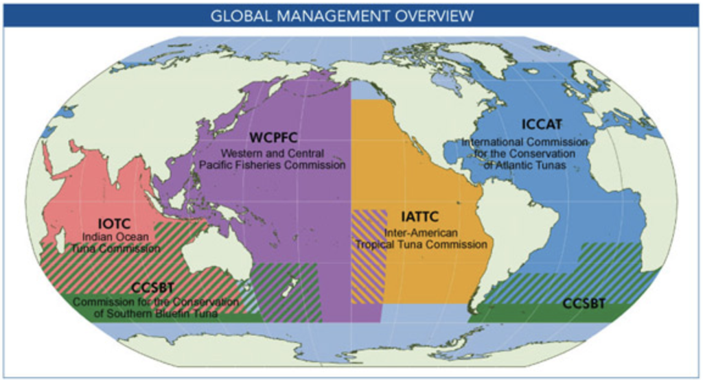

Figure 1: Global overview of tuna managing Regional Fisheries Management Organizations.

For the purposes of this paper, we will be scoping the analysis to the RFMO responsible for the Western Pacific, the **Western and Central Pacific Fisheries Commission (WCPFC)**. In order for vessels to fish for highly migratory species of fish (i.e. all types of tuna, marlin, etc.) in the Western and Central Pacific, they must be registered with WCPFC and follow its regulations. The WCPFC Convention Area covers over 12 million square nautical miles, or 20% of the Earth’s oceans (see Figure Figure 2).

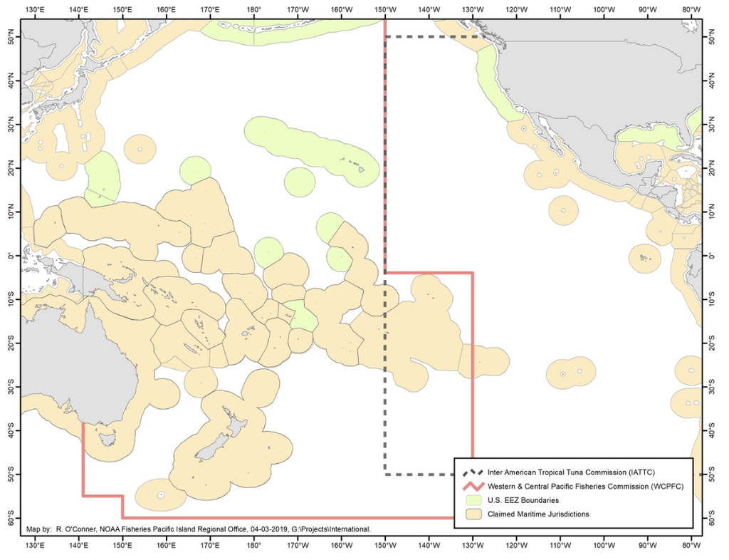

There are currently over 3,000 vessels registered under the WCPFC, with the most prominent flag states[^2] being China, Japan, Chinese Taipei (Taiwan), and the Philippines (“WCPFC RFV” n.d.). The WCPFC regulates when, where, what, and how these vessels are allowed to fish, but only on the High Seas outside any other country’s Exclusive Economic Zone (EEZ)[^3]. In order for a vessel to be registered with WCPFC, it must also be flagged[^4] in a country that is a member of the WCPFC[^5].

With 26 member states and over 3,000 vessels, along with a large number of owners, operators, and corporations, the web of associations within the fisheries sector for just this RFMO is vast.

Using publicly available data on ship registration and associated information, we hope to examine the data for relationships that might indicate potential concerns or provide insight into the commercial fishing enterprise for this area of the globe.

## 1.2 Previous Work

Previous research has applied network analysis to study fishing practices and fisheries governance. Given the complex and layered relationships that exist between different entities and information flows, network-based approaches provide a way to model and visualize systems that would otherwise be extremely difficult to capture holistically. For instance, Dell’Apa et al. (2013) used Social Network Analysis (SNA) to analyze trade flows of spiny dogfish, revealing how global trade relationships impact regional conservation outcomes and suggesting that trade regulations could promote sustainability.

Network analysis has been used to relate information tied to vessels and their activities. For example, in Ford, Bergseth, and Wilcox (2018), researchers used SNA to identify key ships operating in the Indian Ocean fishing industry. By analyzing AIS data, they inferred relationships between vessels operating in close proximity and found that refrigerated cargo vessels (reefers) and bunkering ships played pivotal roles within the network, as evidenced by high eigenvector centrality scores. Network Analysis has also been used to understand vessel movements and behaviors outside of the fisheries scope. The highly cited Varlamis et al. (2021), explored the use of AIS data to build vessel-traffic networks. While their work focused more on visualizing maritime traffic patterns than directly addressing overfishing, it underscores how network-based data structures can enable analysis across diverse fisheries contexts.

Network analysis has also been applied to social and governance networks. For instance, Marín and Berkes (2010) examined co-management networks in Chilean small-scale fisheries, finding that power was highly centralized among government institutions and recommending policy changes to promote participatory governance. Such qualitative analyses underscore how network methods can extend beyond purely quantitative data to reveal institutional and social dynamics relevant to fisheries management.

The qualitative dimension remains important for future work that might follow quantitative analysis. As an example, Dell’Apa et al. (2014) expanded on earlier research to explore how stakeholder networks influence fishery management policies for spiny dogfish, highlighting the role of network structures in shaping effective governance.

Another study, Mulvaney et al. (2015), employed survey data to establish connections among stakeholders in the Great Lakes’ local fisheries network. While the study highlighted methodological constraints due to reliance on survey responses, it also showed that informal relationships accounted for a significant share of network connections, revealing an under-explored layer of fisheries governance.

A particularly promising area involves transforming fisheries data into network structures to reveal hidden dynamics. A critical component of Nogueira et al. (2023)’s analysis of fisheries in the Azores was the conversion of time-series catch data into network graphs. This time-sensitive approach enabled identification of key species associations and critical fishing nodes relevant to sustainable management strategies. Such techniques illustrate the potential for network analysis not only to describe existing systems but also to support proactive recommendations for sustainability.

Across this body of work, researchers have applied diverse network approaches – from social networks and trade networks to vessel proximity networks – to uncover the structure and function of complex fisheries systems. These examples underscore the versatility of network analysis as a framework for exploring fisheries data. While each study focuses on a particular region or problem, collectively they demonstrate the value of network perspectives in understanding the multi-layered realities of marine resource use and governance.

This paper builds on these foundations by exploring how network analysis might be applied to the WCPFC fisheries context. However, our initial focus remains on developing methods and understanding the available data, rather than drawing definitive conclusions at this stage.

# 2 Data

Understanding the fisheries landscape in the Wester Pacific requires integrating information from multiple domains. A large part of this analysis was creating this robust data set, which enabled the construction of a fisheries network and the application of network analysis methods to address the problem. Accordingly, we relied on datasets from international organizations, satellite-based monitoring platforms, and open-source geospatial repositories.

## 2.1 Data Collection

The first data source was the WCPFC’s Registry of Fishing Vessels (RFV) (“WCPFC RFV” n.d.). This is a list of approximately 3,000 vessels that are authorized to fish within the WCPFC’s Convention Area. The RFV contains the whole of the vessels’ registration information, including official name, flag state, identification numbers, home port, vessel type, and owner information.

Global Fishing Watch applies their own “fishing detection algorithm based on changes in vessel speed and direction”, so that only the Apparent Fishing Effort was collected (Global Fishing Watch 2025b). Fishing vessel AIS activity was collected from the major fishing areas, EEZs and High Seas Pockets[^6], within the Western Pacific. The exact areas and their boundaries can be found in Section 6.1. The activity was collected for each individual area from 01JUL2024 to 01JUL2025, with each observation identifying the vessel and how many hours they exhibited fishing activity in that time period. The full breakdown of Global Fishing Watch’s fishing vessel activity algorithm can be found in their 2018 paper, Kroodsma et al. (2018).

It should also be noted that WCPFC also requires the use of Vessel Monitoring Systems, or VMS, for vessels fishing on the High Seas within the Convention Area. However, VMS is only accessible by those member states and agencies and organizations dedicated to fishers and is not publicly available. For that reason, VMS was not included in this analysis.